# OUTPUT.htm

PRESERVE.  
SET DECIMAL DOT.  
GET DATA /TYPE=TXT  
/FILE="C:\Users\jb1094\Downloads\ice_bucket.csv"  
/ENCODING='UTF8'  
/DELIMITERS="\t"  
/QUALIFIER='"'  
/ARRANGEMENT=DELIMITED  
/FIRSTCASE=2  
/DATATYPEMIN PERCENTAGE=95.0  
/VARIABLES=  
upload_day AUTO  
/MAP.  
RESTORE.  
CACHE.  
EXECUTE.  
Data written to the working file.  
1 variables and 2323000 cases written.  
Variable: upload_day Type: Number Format : F2  
Substitute the following to build syntax for these data.  
/VARIABLES=  
upload_day F2  
DATASET NAME DataSet1 WINDOW=FRONT.  
* Chart Builder.  
GGRAPH  
/GRAPHDATASET NAME="graphdataset" VARIABLES=upload_day MISSING=LISTWISE REPORTMISSING=NO  
/GRAPHSPEC SOURCE=INLINE.  
BEGIN GPL  
SOURCE: s=userSource(id("graphdataset"))  
DATA: upload_day=col(source(s), name("upload_day"))  
GUIDE: axis(dim(1), label("upload_day"))  
GUIDE: axis(dim(2), label("Frequency"))  
GUIDE: text.title(label("Simple Histogram of upload_day"))  
ELEMENT: interval(position(summary.count(bin.rect(upload_day))), shape.interior(shape.square))  
END GPL.

GGraph

NotesNotes, table, 0 levels of column headers and 2 levels of row headers, table with 3 columns and 12 rows

| Output Created |  | 17-MAR-2021 12:46:29 |
| --- | --- | --- |
| Comments |  |  |
| Input | Data | C:\Users\jb1094\Downloads\ice_bucket.csv |
|  | Active Dataset | DataSet1 |
|  | Filter | <none> |
|  | Weight | <none> |
|  | Split File | <none> |
|  | N of Rows in Working Data File | 2323000 |
| Syntax |  | GGRAPH /GRAPHDATASET NAME="graphdataset" VARIABLES=upload_day MISSING=LISTWISE REPORTMISSING=NO /GRAPHSPEC SOURCE=INLINE. BEGIN GPL SOURCE: s=userSource(id("graphdataset")) DATA: upload_day=col(source… |
| Resources | Processor Time | 00:00:05.42 |
|  | Elapsed Time | 17-MAR-2021 12:46:29 |

Graph

Simple Histogram of upload_day

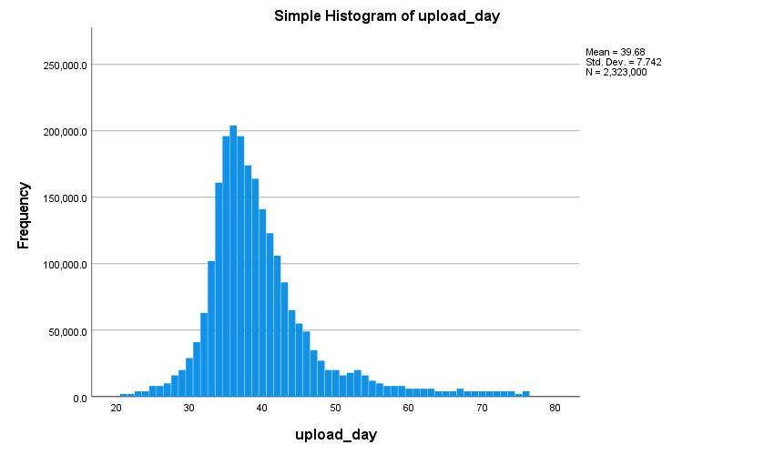

upload_day is unimodal, positively skewed

DATASET ACTIVATE DataSet1.  
DATASET CLOSE DataSet2.  
DATASET ACTIVATE DataSet1.  
DATASET CLOSE DataSet3.  
PRESERVE.  
SET DECIMAL DOT.  
GET DATA /TYPE=TXT  
/FILE="C:\Users\jb1094\Downloads\nhanes_selectvars_n500.csv"  
/ENCODING='UTF8'  
/DELIMITERS=","  
/QUALIFIER='"'  
/ARRANGEMENT=DELIMITED  
/FIRSTCASE=2  
/DATATYPEMIN PERCENTAGE=95.0  
/VARIABLES=  
ID AUTO  
Gender AUTO  
Age AUTO  
Weight AUTO  
Height AUTO  
AlcoholDay AUTO  
Depressed AUTO  
BMI AUTO  
SleepHrsNight AUTO  
SleepTrouble AUTO  
/MAP.  
RESTORE.  
CACHE.  
EXECUTE.  
Data written to the working file.  
10 variables and 500 cases written.  
Variable: ID Type: Number Format : F5  
Variable: Gender Type: String Format : A6  
Variable: Age Type: Number Format : F2  
Variable: Weight Type: Number Format : F5.1 One or more values were set to system-missing.  
Variable: Height Type: Number Format : F5.1 One or more values were set to system-missing.  
Variable: AlcoholDay Type: String Format : A2  
Variable: Depressed Type: String Format : A7  
Variable: BMI Type: Number Format : F5.2 One or more values were set to system-missing.  
Variable: SleepHrsNight Type: String Format : A2  
Variable: SleepTrouble Type: String Format : A3  
Substitute the following to build syntax for these data.  
/VARIABLES=  
ID F5  
Gender A6  
Age F2  
Weight F5.1  
Height F5.1  
AlcoholDay A2  
Depressed A7  
BMI F5.2  
SleepHrsNight A2  
SleepTrouble A3  
DATASET NAME DataSet4 WINDOW=FRONT.  
EXAMINE VARIABLES=Height  
/PLOT BOXPLOT HISTOGRAM NPPLOT  
/COMPARE GROUPS  
/STATISTICS DESCRIPTIVES  
/CINTERVAL 95  
/MISSING LISTWISE  
/NOTOTAL.

### Height is negatively skewed, non-normal, lots of low value outliers

Explore

NotesNotes, table, 0 levels of column headers and 2 levels of row headers, table with 3 columns and 14 rows

| Output Created |  | 17-MAR-2021 13:10:13 |
| --- | --- | --- |
| Comments |  |  |
| Input | Data | C:\Users\jb1094\Downloads\nhanes_selectvars_n500.csv |
|  | Active Dataset | DataSet4 |
|  | Filter | <none> |
|  | Weight | <none> |
|  | Split File | <none> |
|  | N of Rows in Working Data File | 500 |
| Missing Value Handling | Definition of Missing | User-defined missing values for dependent variables are treated as missing. |
|  | Cases Used | Statistics are based on cases with no missing values for any dependent variable or factor used. |
| Syntax |  | EXAMINE VARIABLES=Height /PLOT BOXPLOT HISTOGRAM NPPLOT /COMPARE GROUPS /STATISTICS DESCRIPTIVES /CINTERVAL 95 /MISSING LISTWISE /NOTOTAL. |
| Resources | Processor Time | 00:00:00.52 |
|  | Elapsed Time | 17-MAR-2021 13:10:13 |

[DataSet4]

Case Processing Summary

|  | Cases Valid N | Cases Valid Percent | Cases Missing N | Cases Missing Percent | Cases Total N | Percent |
| --- | --- | --- | --- | --- | --- | --- |
| Height | 477 | 95.4% | 23 | 4.6% | 500 | 100.0% |

Descriptives

|  |  |  | Statistic | Std. Error |
| --- | --- | --- | --- | --- |
| Height | Mean |  | 159.859 | 1.0004 |
|  | 95% Confidence Interval for Mean | Lower Bound | 157.894 |  |
|  |  | Upper Bound | 161.825 |  |
|  | 5% Trimmed Mean |  | 161.858 |  |
|  | Median |  | 165.400 |  |
|  | Variance |  | 477.393 |  |
|  | Std. Deviation |  | 21.8493 |  |
|  | Minimum |  | 84.9 |  |
|  | Maximum |  | 194.5 |  |
|  | Range |  | 109.6 |  |
|  | Interquartile Range |  | 19.5 |  |
|  | Skewness |  | -1.546 | .112 |
|  | Kurtosis |  | 2.104 | .223 |

Tests of Normality

|  | Kolmogorov-Smirnov<sup>a</sup> Statistic | Kolmogorov-Smirnov<sup>a</sup> df | Kolmogorov-Smirnov<sup>a</sup> Sig. | Shapiro-Wilk Statistic | Shapiro-Wilk df | Sig. |
| --- | --- | --- | --- | --- | --- | --- |
| Height | .158 | 477 | .000 | .844 | 477 | .000 |

a. Lilliefors Significance Correction

Height

Histogram

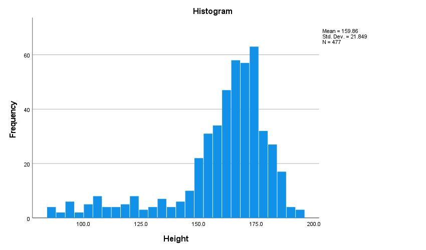

Normal Q-Q Plot

Normal Q-Q Plot of Height

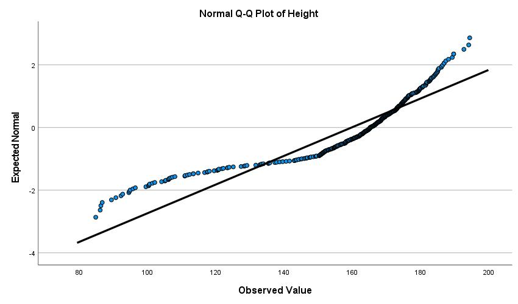

Detrended Normal Q-Q Plot

Detrended Normal Q-Q Plot of Height

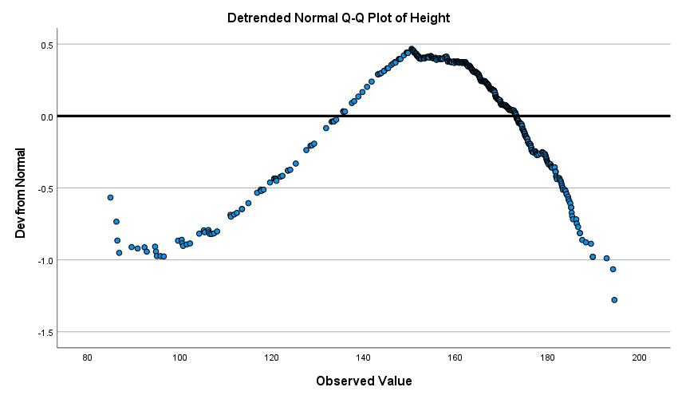

Boxplot

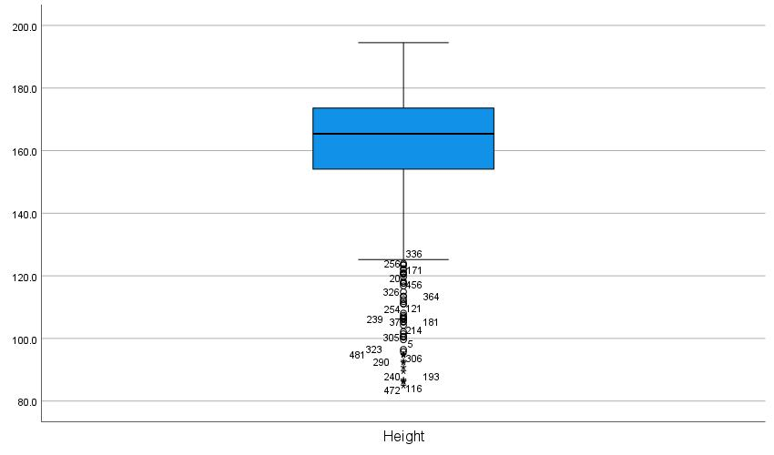

USE ALL.  
COMPUTE filter_$=(Age >= 18).  
VARIABLE LABELS filter_$ 'Age >= 18 (FILTER)'.  
VALUE LABELS filter_$ 0 'Not Selected' 1 'Selected'.  
FORMATS filter_$ (f1.0).  
FILTER BY filter_$.  
EXECUTE.  
EXAMINE VARIABLES=Height  
/PLOT BOXPLOT HISTOGRAM NPPLOT  
/COMPARE GROUPS  
/STATISTICS DESCRIPTIVES  
/CINTERVAL 95  
/MISSING LISTWISE  
/NOTOTAL.

For individuals age 18 or older, Height is normally distributed, no outliers, likely due to the age range (young individuals that have not reached adult Height)

Explore

NotesNotes, table, 0 levels of column headers and 2 levels of row headers, table with 3 columns and 14 rows

| Output Created |  | 17-MAR-2021 13:15:10 |
| --- | --- | --- |
| Comments |  |  |
| Input | Data | C:\Users\jb1094\Downloads\nhanes_selectvars_n500.csv |
|  | Active Dataset | DataSet4 |
|  | Filter | Age >= 18 (FILTER) |
|  | Weight | <none> |
|  | Split File | <none> |
|  | N of Rows in Working Data File | 339 |
| Missing Value Handling | Definition of Missing | User-defined missing values for dependent variables are treated as missing. |
|  | Cases Used | Statistics are based on cases with no missing values for any dependent variable or factor used. |
| Syntax |  | EXAMINE VARIABLES=Height /PLOT BOXPLOT HISTOGRAM NPPLOT /COMPARE GROUPS /STATISTICS DESCRIPTIVES /CINTERVAL 95 /MISSING LISTWISE /NOTOTAL. |
| Resources | Processor Time | 00:00:00.50 |
|  | Elapsed Time | 17-MAR-2021 13:15:10 |

Case Processing Summary

|  | Cases Valid N | Cases Valid Percent | Cases Missing N | Cases Missing Percent | Cases Total N | Percent |
| --- | --- | --- | --- | --- | --- | --- |
| Height | 336 | 99.1% | 3 | 0.9% | 339 | 100.0% |

Descriptives

|  |  |  | Statistic | Std. Error |
| --- | --- | --- | --- | --- |
| Height | Mean |  | 168.629 | .5575 |
|  | 95% Confidence Interval for Mean | Lower Bound | 167.533 |  |
|  |  | Upper Bound | 169.726 |  |
|  | 5% Trimmed Mean |  | 168.680 |  |
|  | Median |  | 168.750 |  |
|  | Variance |  | 104.427 |  |
|  | Std. Deviation |  | 10.2189 |  |
|  | Minimum |  | 143.1 |  |
|  | Maximum |  | 194.5 |  |
|  | Range |  | 51.4 |  |
|  | Interquartile Range |  | 13.9 |  |
|  | Skewness |  | -.070 | .133 |
|  | Kurtosis |  | -.399 | .265 |

Tests of Normality

|  | Kolmogorov-Smirnov<sup>a</sup> Statistic | Kolmogorov-Smirnov<sup>a</sup> df | Kolmogorov-Smirnov<sup>a</sup> Sig. | Shapiro-Wilk Statistic | Shapiro-Wilk df | Sig. |
| --- | --- | --- | --- | --- | --- | --- |
| Height | .035 | 336 | .200* | .995 | 336 | .432 |

a. Lilliefors Significance Correction  
*. This is a lower bound of the true significance.

Height

Histogram

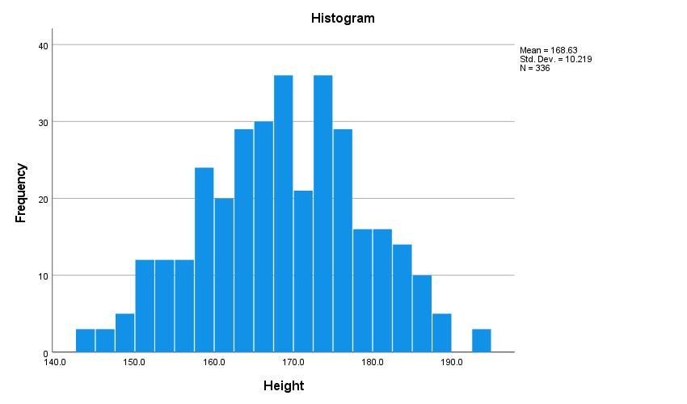

Normal Q-Q Plot

Normal Q-Q Plot of Height

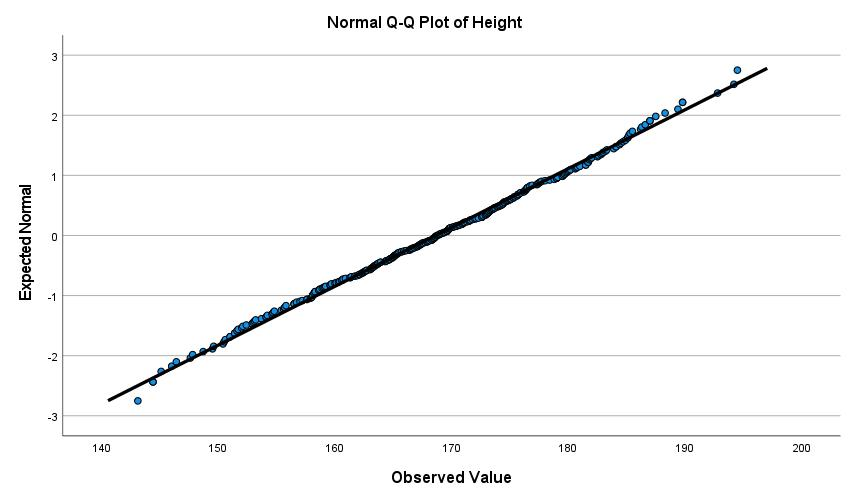

Detrended Normal Q-Q Plot

Detrended Normal Q-Q Plot of Height

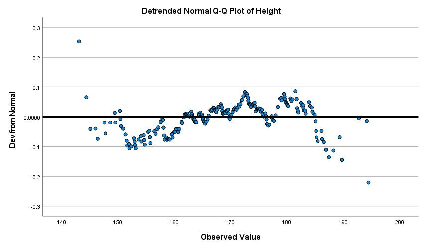

Boxplot

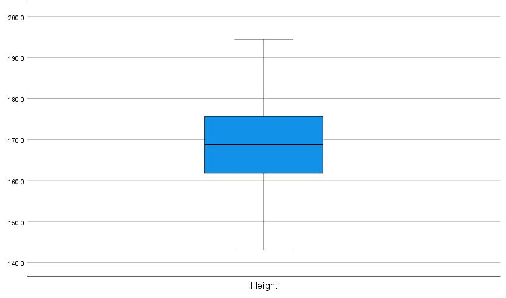

PRESERVE.  
SET DECIMAL DOT.  
GET DATA /TYPE=TXT  
/FILE="C:\Users\jb1094\Downloads\cort-hypothetical.txt"  
/ENCODING='UTF8'  
/DELCASE=LINE  
/DELIMITERS="\t"  
/ARRANGEMENT=DELIMITED  
/FIRSTCASE=2  
/DATATYPEMIN PERCENTAGE=95.0  
/VARIABLES=  
ID AUTO  
cortisol_baseline AUTO  
/MAP.  
RESTORE.  
CACHE.  
EXECUTE.  
Data written to the working file.  
2 variables and 400 cases written.  
Variable: ID Type: Number Format : F5  
Variable: cortisol_baseline Type: Number Format : F6.3 One or more values were set to system-missing.  
Substitute the following to build syntax for these data.  
/VARIABLES=  
ID F5  
cortisol_baseline F6.3  
DATASET NAME DataSet5 WINDOW=FRONT.  
EXAMINE VARIABLES=cortisol_baseline  
/PLOT BOXPLOT HISTOGRAM NPPLOT  
/COMPARE GROUPS  
/STATISTICS DESCRIPTIVES  
/CINTERVAL 95  
/MISSING LISTWISE  
/NOTOTAL.

cortisol_baseline is positively skewed, non-normal

Explore

NotesNotes, table, 0 levels of column headers and 2 levels of row headers, table with 3 columns and 14 rows

| Output Created |  | 17-MAR-2021 13:20:00 |
| --- | --- | --- |
| Comments |  |  |
| Input | Data | C:\Users\jb1094\Downloads\cort-hypothetical.txt |
|  | Active Dataset | DataSet5 |
|  | Filter | <none> |
|  | Weight | <none> |
|  | Split File | <none> |
|  | N of Rows in Working Data File | 400 |
| Missing Value Handling | Definition of Missing | User-defined missing values for dependent variables are treated as missing. |
|  | Cases Used | Statistics are based on cases with no missing values for any dependent variable or factor used. |
| Syntax |  | EXAMINE VARIABLES=cortisol_baseline /PLOT BOXPLOT HISTOGRAM NPPLOT /COMPARE GROUPS /STATISTICS DESCRIPTIVES /CINTERVAL 95 /MISSING LISTWISE /NOTOTAL. |
| Resources | Processor Time | 00:00:00.47 |
|  | Elapsed Time | 17-MAR-2021 13:20:00 |

[DataSet5]

Case Processing Summary

|  | Cases Valid N | Cases Valid Percent | Cases Missing N | Cases Missing Percent | Cases Total N | Percent |
| --- | --- | --- | --- | --- | --- | --- |
| cortisol_baseline | 390 | 97.5% | 10 | 2.5% | 400 | 100.0% |

Descriptives

|  |  |  | Statistic | Std. Error |
| --- | --- | --- | --- | --- |
| cortisol_baseline | Mean |  | 4.79593 | .170363 |
|  | 95% Confidence Interval for Mean | Lower Bound | 4.46098 |  |
|  |  | Upper Bound | 5.13088 |  |
|  | 5% Trimmed Mean |  | 4.43909 |  |
|  | Median |  | 3.93150 |  |
|  | Variance |  | 11.319 |  |
|  | Std. Deviation |  | 3.364405 |  |
|  | Minimum |  | .389 |  |
|  | Maximum |  | 28.294 |  |
|  | Range |  | 27.905 |  |
|  | Interquartile Range |  | 3.281 |  |
|  | Skewness |  | 2.453 | .124 |
|  | Kurtosis |  | 10.088 | .247 |

Tests of Normality

|  | Kolmogorov-Smirnov<sup>a</sup> Statistic | Kolmogorov-Smirnov<sup>a</sup> df | Kolmogorov-Smirnov<sup>a</sup> Sig. | Shapiro-Wilk Statistic | Shapiro-Wilk df | Sig. |
| --- | --- | --- | --- | --- | --- | --- |
| cortisol_baseline | .140 | 390 | .000 | .805 | 390 | .000 |

a. Lilliefors Significance Correction

cortisol_baseline

Histogram

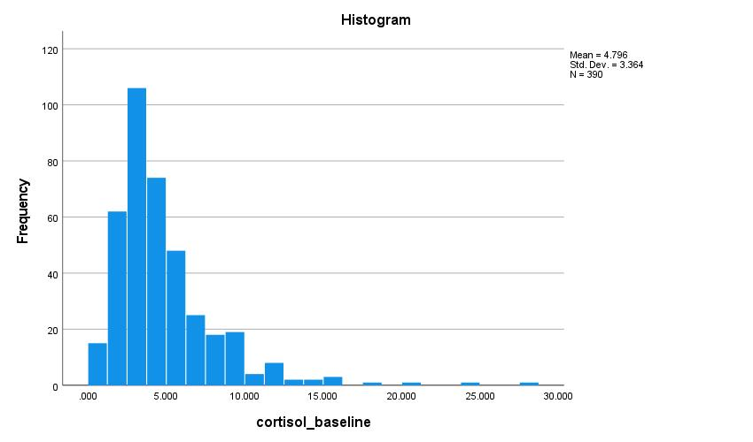

Normal Q-Q Plot

Normal Q-Q Plot of cortisol_baseline

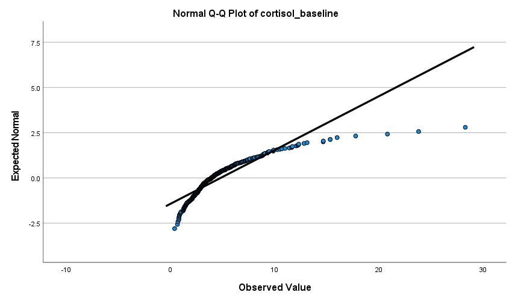

Detrended Normal Q-Q Plot

Detrended Normal Q-Q Plot of cortisol_baseline

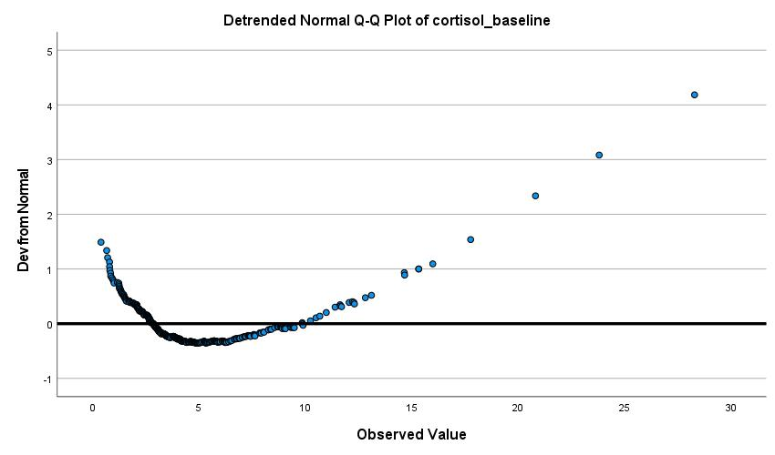

Boxplot

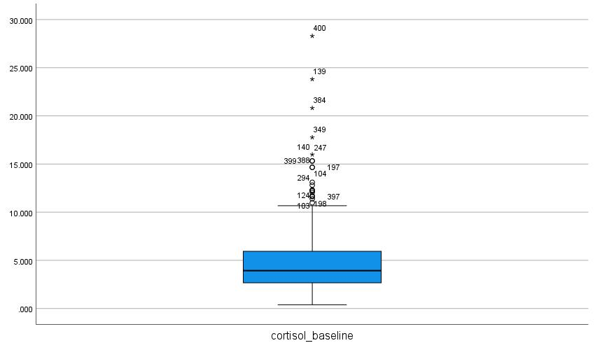

COMPUTE log_cortisol_baseline=LN(cortisol_baseline).  
EXECUTE.  
EXAMINE VARIABLES=log_cortisol_baseline  
/PLOT BOXPLOT HISTOGRAM NPPLOT  
/COMPARE GROUPS  
/STATISTICS DESCRIPTIVES  
/CINTERVAL 95  
/MISSING LISTWISE  
/NOTOTAL.

log transformed cortisol_baseline is (close to) normally distributed

Explore

NotesNotes, table, 0 levels of column headers and 2 levels of row headers, table with 3 columns and 14 rows

| Output Created |  | 17-MAR-2021 13:24:16 |
| --- | --- | --- |
| Comments |  |  |
| Input | Data | C:\Users\jb1094\Downloads\cort-hypothetical.txt |
|  | Active Dataset | DataSet5 |
|  | Filter | <none> |
|  | Weight | <none> |
|  | Split File | <none> |
|  | N of Rows in Working Data File | 400 |
| Missing Value Handling | Definition of Missing | User-defined missing values for dependent variables are treated as missing. |
|  | Cases Used | Statistics are based on cases with no missing values for any dependent variable or factor used. |
| Syntax |  | EXAMINE VARIABLES=log_cortisol_baseline /PLOT BOXPLOT HISTOGRAM NPPLOT /COMPARE GROUPS /STATISTICS DESCRIPTIVES /CINTERVAL 95 /MISSING LISTWISE /NOTOTAL. |
| Resources | Processor Time | 00:00:00.47 |
|  | Elapsed Time | 17-MAR-2021 13:24:16 |

Case Processing Summary

|  | Cases Valid N | Cases Valid Percent | Cases Missing N | Cases Missing Percent | Cases Total N | Percent |
| --- | --- | --- | --- | --- | --- | --- |
| log_cortisol_baseline | 390 | 97.5% | 10 | 2.5% | 400 | 100.0% |

Descriptives

|  |  |  | Statistic | Std. Error |
| --- | --- | --- | --- | --- |
| log_cortisol_baseline | Mean |  | 1.3687 | .03226 |
|  | 95% Confidence Interval for Mean | Lower Bound | 1.3053 |  |
|  |  | Upper Bound | 1.4322 |  |
|  | 5% Trimmed Mean |  | 1.3758 |  |
|  | Median |  | 1.3690 |  |
|  | Variance |  | .406 |  |
|  | Std. Deviation |  | .63702 |  |
|  | Minimum |  | -.94 |  |
|  | Maximum |  | 3.34 |  |
|  | Range |  | 4.29 |  |
|  | Interquartile Range |  | .80 |  |
|  | Skewness |  | -.149 | .124 |
|  | Kurtosis |  | .528 | .247 |

Tests of Normality

|  | Kolmogorov-Smirnov<sup>a</sup> Statistic | Kolmogorov-Smirnov<sup>a</sup> df | Kolmogorov-Smirnov<sup>a</sup> Sig. | Shapiro-Wilk Statistic | Shapiro-Wilk df | Sig. |
| --- | --- | --- | --- | --- | --- | --- |
| log_cortisol_baseline | .047 | 390 | .041 | .994 | 390 | .139 |

a. Lilliefors Significance Correction

log_cortisol_baseline

Histogram

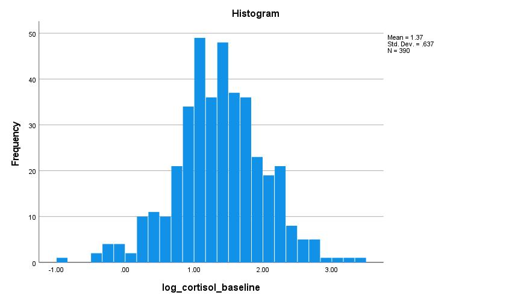

Normal Q-Q Plot

Normal Q-Q Plot of log_cortisol_baseline

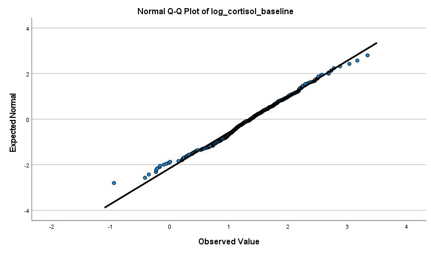

Detrended Normal Q-Q Plot

Detrended Normal Q-Q Plot of log_cortisol_baseline

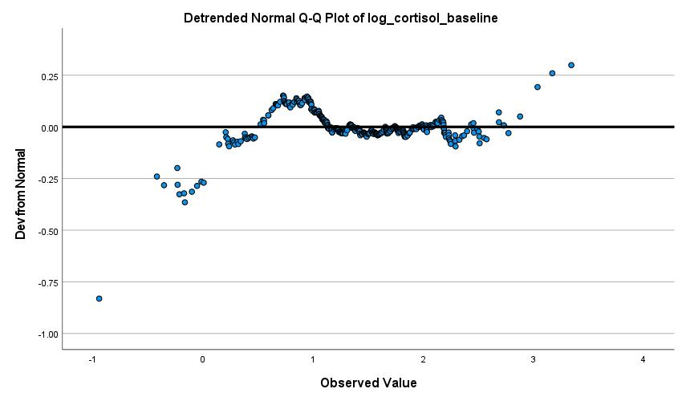

Boxplot

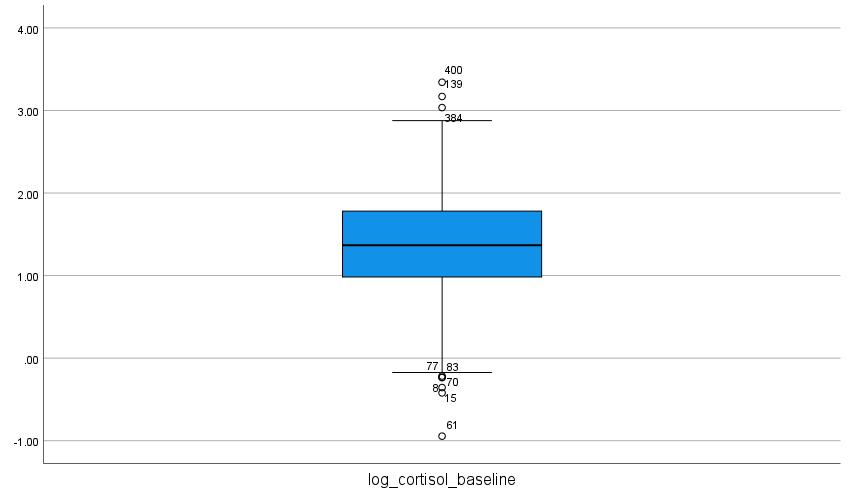